# R packaging

## 3.2 R code :

Let’s consider few function for raster and image modification. First, our new functions and worflow will depend on other packages that we need to load:

```r
library(spatstat)
library(glue)
```

Next, we want to create an image that display a gradient along the area of interest. Thus set the coordinates of our gridded area (resolution) and define a function which will evaluate the values $v1$ across our space. The last step is to create the image using `as.im()`.

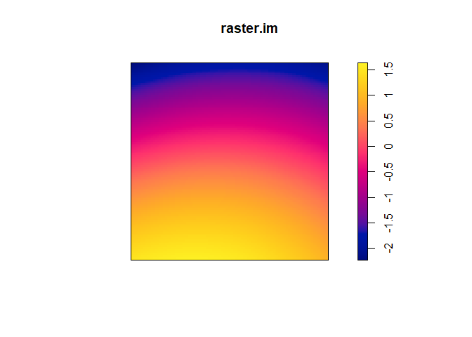

```r
set.seed(113)
XY = expand.grid(seq(0, 100, 1), seq(0, 100, 1))
X = XY[,1]
Y = XY[,2]

v1 = (X - 30)^2 + (Y + 80)^2 - 0.5*X*Y
v1 = -1*scale(v1)

raster.im = as.im(data.frame(x = X, y = Y, z = v1))
plot(raster.im)
```

These different steps can be combined in a function, where we can play with $n_col$ and $n_row$ to establish a random gradient within space of different sizes. Let’s call this function `RandomGradient`

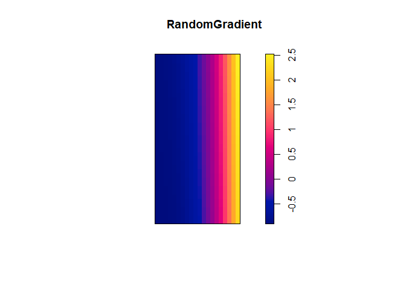

```r
### create image/raster

RandomGradient <- function(n_col, n_row, plot = TRUE){

  #create the image matrix
  XY = expand.grid(seq(0, n_col-1, 1), seq(0, n_row-1, 1))
  X = XY[,1]
  Y = XY[,2]

  # randomize a gradient function
  math_op <- c("-", "+")
  exp_size <- c("^1", "^2", "^3")

  op_1 <- sample(math_op, 1)
  op_2 <- sample(math_op, 1)
  op_3 <- sample(math_op, 1)
  op_4 <- sample(math_op, 1)

  exp_x <- sample(exp_size, 1)
  exp_y <- sample(exp_size, 1)

  val_1 <- sample(seq(0, 100, 1), 1)
  val_2 <- sample(seq(0, 100, 1), 1)
  val_3 <- sample(seq(0, 1, 0.01), 1)

  # set the gradient function
  str_expression <-  glue(
    "(X{exp_x} {op_1} {val_1}) {op_2} (Y{exp_y} {op_3} {val_2}) {op_4} ({val_3}*X*Y)"
  )

  # Create the raster image
  v1 <- eval(parse(text = str_expression))
  v1 = scale(v1)

  raster.im = as.im(data.frame(x = X, y = Y, z = v1))

  if(plot) plot(raster.im, main = "RandomGradient")

  raster.im
  return(raster.im)
}

Grad1 = RandomGradient(n_col=20, n_row=40)
```

If we change the value of $n_col$ and $n_row$:

```r
Grad2 = RandomGradient(n_col=40, n_row=40)
```

[figure not shown]

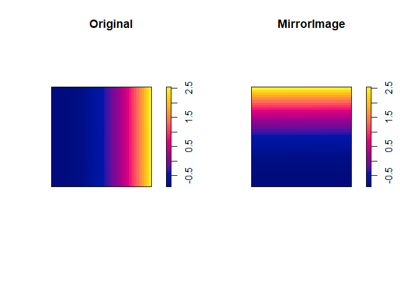

```r
MirrorImage = function(Rast, direction = c("horizontal", "vertical"),
                       plot = TRUE){

  if(direction == "horizontal"){
    mat1 <- apply(Rast$v, 2, rev)
    m_raster = as.im(t(mat1))

  }

  if(direction == "vertical"){
    mat1 <- apply(Rast$v, 1, rev)
    m_raster = as.im(t(mat1))
  }

  if(plot){
    par(mfrow=c(1,2))
    plot(Rast, main = "Original")
    plot(m_raster, main = "MirrorImage")
  }

  m_raster
  return(m_raster)
}

Grad2.hz = MirrorImage(Grad2, direction = "horizontal")
```

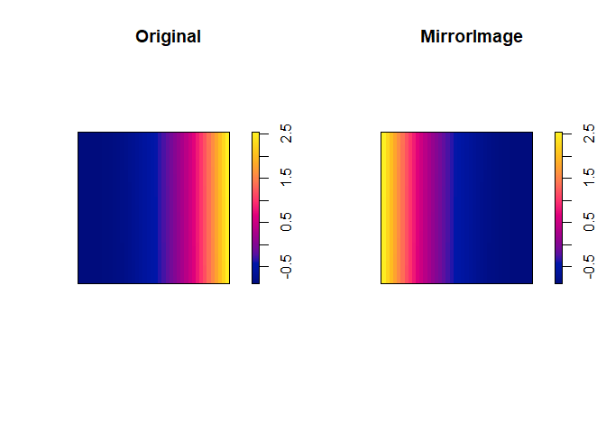

```r
Grad2.vt = MirrorImage(Grad2, direction = "vertical")
```

Finally, we can create a function that modifies the direction of the gradient by playing with $x$ and $y$ or the strength of the gradient with $z$ in the input values in the function `WiggleImage`:

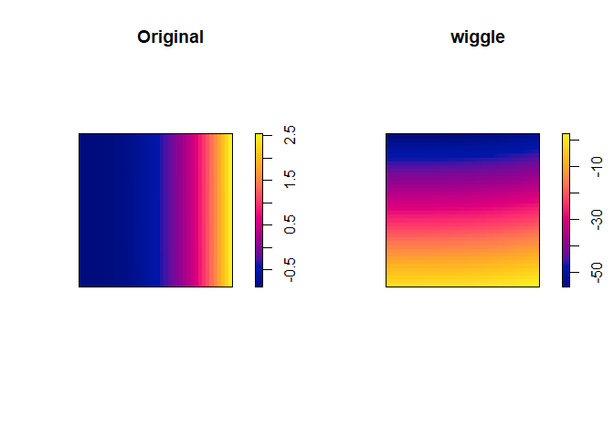

```r
WiggleImage = function(Rast, x=NULL, y=NULL, z=NULL, plot = TRUE){
  Grad.w = Rast

  if(!is.null(x)){
    X = Grad.w$xcol
    Grad.w$v = Grad.w$v + x*X
  }

  if(!is.null(y)){
    Y = Grad.w$yrow
    Grad.w$v = Grad.w$v + x*X + y*Y
  }

   if(!is.null(z)){
    X = Grad.w$xcol
    Y = Grad.w$yrow

    Grad.w$v = Grad.w$v + z*X*Y
  }

  if(plot){
    par(mfrow=c(1,2))
    plot(Rast, main = "Original")
    plot(Grad.w, main = "wiggle")
  }
  return(Grad.w)
}

Rast_change = WiggleImage(Grad2, x = -1, y = 0.6)
```

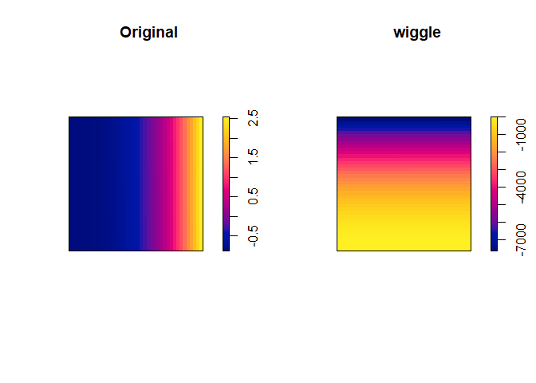

```r
Rast_change2 = WiggleImage(Grad2, z = -5)
```

or we can just add general noise overall:

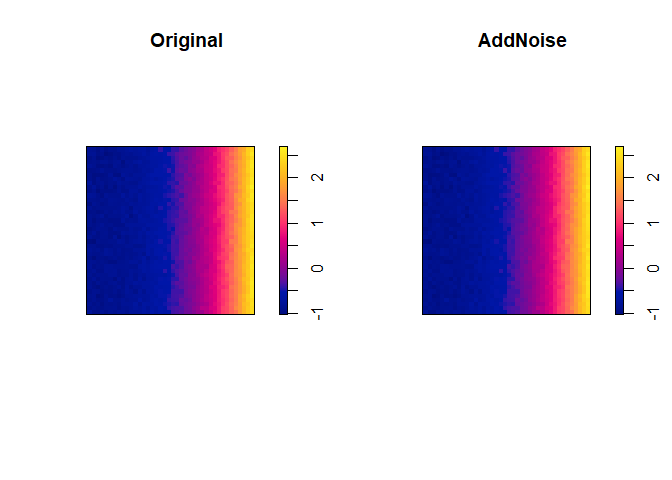

```r
AddNoise <- function(Rast, noise = 0.1, plot = TRUE){
  l_vec <- length(Rast$v)
  add_noise <- rnorm(l_vec, 0, noise)

  Rast$v <- Rast$v + add_noise

  if(plot){
    par(mfrow=c(1,2))
    plot(Rast, main = "Original")
    plot(Rast, main = "AddNoise")
  }
  Rast
  return(Rast)
}

Rast_noise = AddNoise(Grad2, noise = 0.05)
```

Now, we have 4 functions to create our package! Let’s call it `Gradients`. The function created can be organize into one or multiple files if needed.

# 4 Creation and Maintenance (Arthur)

Main packages needed for package development: * devtools: Creation - building o the package * usethis: help with documentation, testing and broadcast * roxygen2: help with the documentation set up * pkgdown: * testthat: testing

! You also need a system builder ! Make sure Rtools is installed which is done differently depending on your system (windows, MacOS, Linux).

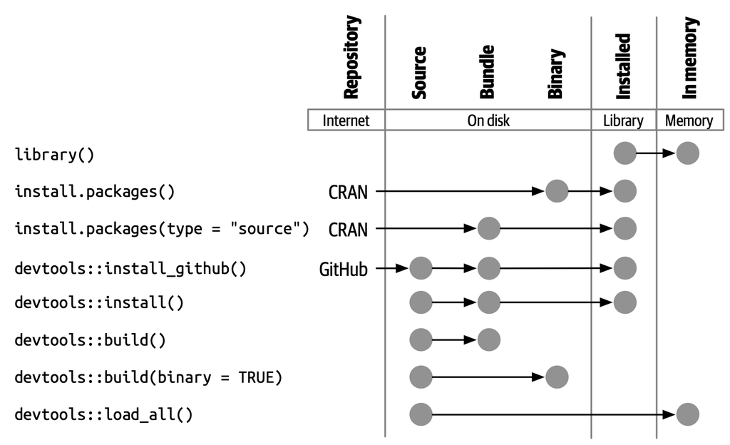

## 4.1 Step by step

Whole R package development workflow:

- `available::available("pkgname")` # check if package name is available (if planning to publish publicly)
- `usethis::create_package("pkgname")` # create the package
- `usethis::use_git()` # set up version control
- `usethis::use_github()` # optional
- `usethis::use_r("myfile")` # creating new R file in the R/ directory
- `usethis::use_data_raw()` # if adding data
- `devtools::load_all()` # try it out in the console
- `usethis::use_package("import-pkgname")` # add package to import (or depends or suggests)

Documentations:

- `usethis::use_package_doc()` # add package documentation
- `usethis::use_pipe()` # if you want to add %>% from `magrittr`
- `usethis::use_vignette("vignette-name")` # add vignette
- `usethis::use_test()` # make test file for active R file

Write some test

- `devtools::test_active_file()` # test active file
- `devtools::test()` # test whole package
- `devtools::build()` # build vignettes
- `devtools::install()` # to install package
- `devtools::check()` # to build and check a package
- `usethis::use_readme_rmd()` # to add a README Rmd file
- `styler::style_pkg()` # optional (commit first, then review changes carefully)
- `usethis::use_pkgdown_github_pages()` # for setting up pkgdown website on github
- `usethis::use_pkgdown()` if not using github pages

# Summary of resources

https://r-pkgs.org/description.html

https://rpubs.com/emitanaka/rladies-lagos-paris-2023

https://github.com/EmyGlblt/Rpackaging